# MEDL_HW07

**Deep Learning for Mechanical Engineering**  
**Homework 07**  
**Due Tuesday, 05/26/2020, 3:30 PM**

TA: Kangsan Lee and Namjeong Lee  
Instructor: Prof. Seungchul Lee  
http://iai.postech.ac.kr/  
Industrial AI Lab at POSTECH

- For your handwritten solution, scan or take a picture of them.
- For your code, only .ipynb file will be graded.
  - Please write your NAME and student ID on your .ipynb files. ex) KangsanLee_20202467_HW07.ipynb
- Please compress all the files to make a single .zip file
  - Please write your NAME and student ID on your .zip files. ex) NamjeongLee_20202467_HW07.zip
  - Submit it to LMS
- Do not submit a printed version of your code. It will not be graded.

# Problem 1: Sign Language Classification with CNN

As we studied in the lecture, CNN can classify images directly. So, the only thing we need to apply CNN is the picture of an object. This advantage allows CNN to applied to various industries. In this problem, we are going to classify sign language by CNN. Then you will able to directly conversate with disabled people even if you don't know sign language.

Download data from [here](https://www.dropbox.com/s/03d30bl0k6f9bqm/sign_language.zip?dl=1)

```python
import tensorflow as tf
import os
import cv2
import numpy as np
from six.moves import cPickle
import matplotlib.pyplot as plt
%matplotlib inline
```

(1) Load and plot 6 random data.

You need to load total 4 files.

- sign_language_test_img.pkl
- sign_language_test_label.pkl
- sign_language_train_img.pkl
- sign_language_train_label.pkl

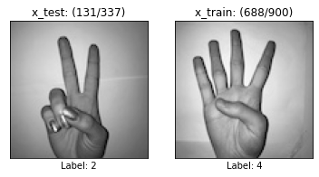

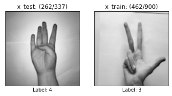

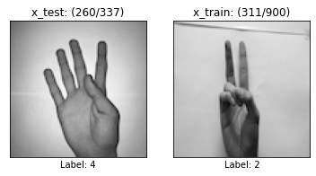

```python
# Your code here
```

(2) Design your CNN structure.

- input
- filter size
- pooling size
- hidden layer
- output

Note: you should check data shape. (CNN input is image!)

```python
# Your code here
```

(3) Train and your model.

```python
# Your code here
```

```
Iter : 0
Cost : 21.172353744506836
Iter : 250
Cost : 0.40283751487731934
Iter : 500
Cost : 0.07468894124031067
Iter : 750
Cost : 0.012453747913241386
Iter : 1000
Cost : 0.005653968546539545
Iter : 1250
Cost : 0.0016396278515458107
Iter : 1500
Cost : 0.001851930283010006
Iter : 1750
Cost : 0.001461406354792416
Iter : 2000
Cost : 0.000874158286023885
Iter : 2250
Cost : 0.0007146745338104665
Iter : 2500
Cost : 0.0006348277674987912
```

(4) Test your model. Calculate accuracy and plot random image with its predicted and true label.

Note: test accuracy should higher than 80%.

```python
# Your code here
```

```
Trainset Accuracy: 100.0%
Testset Accuracy: 89.6%
```

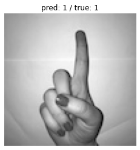

```python
# Your code here
```

# Problem 2: Class Activation Map

Now, we classified sign language by CNN. But even if the model determines the class based on something, we still don't know what it is. In other words, we can't interpret the deep learning model because it is like a black box model! Thus, we want to find the judgment basis of our CNN model by activating the most important region for classification. In this problem, we are going to apply the CAM algorithm to the same dataset with Problem 1.

(1) Design your CAM model structure.

```python
# Your code here
```

(2) Train your CAM model.

```python
# Your code here
```

```
Iter : 0
Cost : 8.651554107666016
Iter : 250
Cost : 1.6188477277755737
Iter : 500
Cost : 1.3945153951644897
Iter : 750
Cost : 1.1621068716049194
Iter : 1000
Cost : 0.9391534924507141
Iter : 1250
Cost : 0.7093023061752319
Iter : 1500
Cost : 0.6159256100654602
Iter : 1750
Cost : 0.5078285932540894
Iter : 2000
Cost : 0.9672945737838745
Iter : 2250
Cost : 0.9073785543441772
Iter : 2500
Cost : 0.7441777586936951
Iter : 2750
Cost : 0.9284403324127197
Iter : 3000
Cost : 0.5911286473274231
Iter : 3250
Cost : 0.6859461069107056
Iter : 3500
Cost : 0.6617854833602905
Iter : 3750
Cost : 0.9329030513763428
Iter : 4000
Cost : 0.5238203406333923
Iter : 4250
Cost : 0.6704736948013306
Iter : 4500
Cost : 0.4676385223865509
Iter : 4750
Cost : 0.637117326259613
Iter : 5000
Cost : 0.6098316311836243
```

(3) Test your model. Calculate the accuracy and plot random image with its predicted and true label and activation map.

Note: test accuracy should higher than 70%.

```python
# Your code here
```

```
Trainset Accuracy: 78.8%
Testset Accuracy: 77.2%
```

```
pred: 3 / true: 3
```

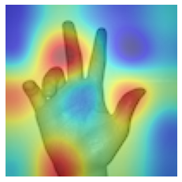

```python
# Your code here
```